# Visualizing the prevalence and occurence of modern slavery globally

Remaking a table from the Global Slavery Index Report (2023) by Walk Free

R

#MakeoverMonday

gt

bubble-chart

Author

[Mickey Rafa](https://mrafa3.github.io/)

Published

December 12, 2024

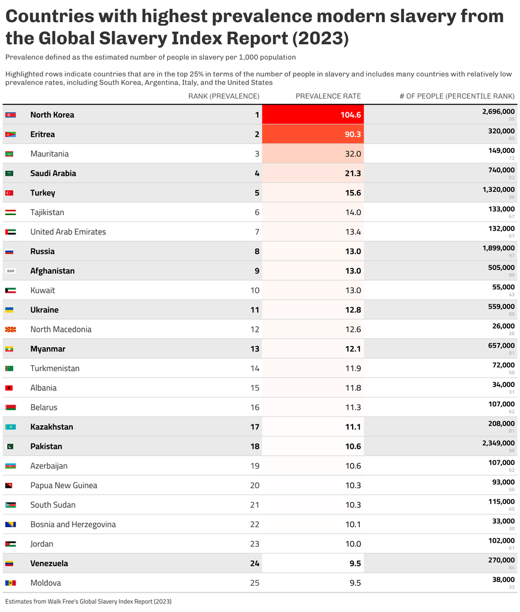

Figure 1: Table illustrating the country-level prevalence and absolute estimates of modern slavery. Data source: Walk Free’s Global Slavery Index Report (2023).

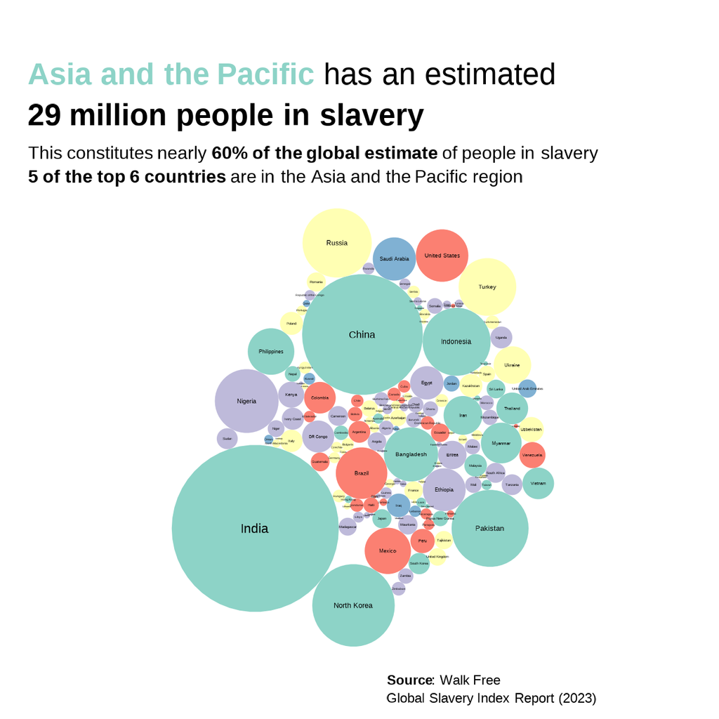

Figure 2: Bubble plot illustrating the country-level estimates of enslaved people. Bubble size corresponds with the estimated number of people in slavery in that country, and color corresponds to the geographic region. Data source: Walk Free’s Global Slavery Index Report (2023).

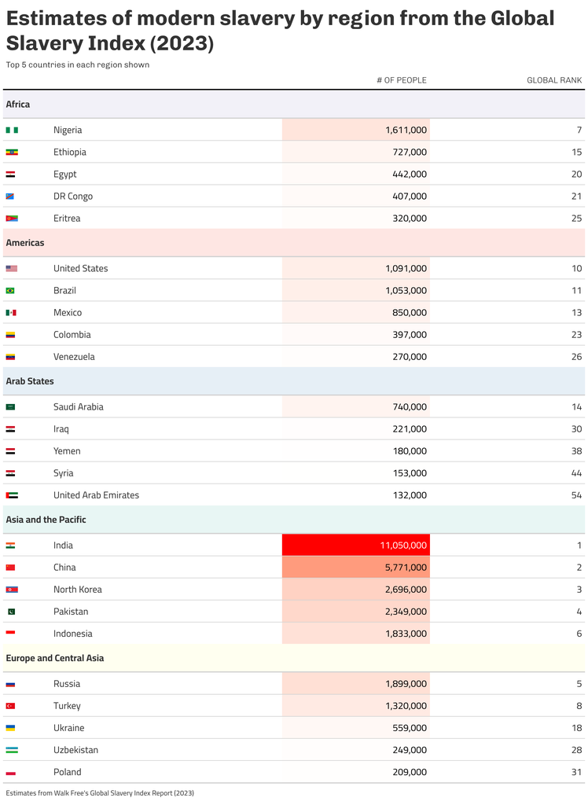

Figure 3: Companion chart with Figure 2, showing the five countries in each region with the largest estimates of enslaved people. Data source: Walk Free’s Global Slavery Index Report (2023).

# 1. Load Packages & Setup

```r
if (!require("pacman")) install.packages("pacman")
pacman::p_load(
    tidyverse,
    devtools,
    httr,
    readxl,
    dlookr,
    ggtext,
    gt,
    gtExtras,  #for font awesome icons in gt tables
    ggbump,
    ggcirclepack,
    showtext,
    tidycountries,
    janitor,   #for clean_names()
    scales,
    patchwork,
    htmltools, #for tagList()
    glue,
    here,
    geomtextpath
)

# install_github("EvaMaeRey/ggcirclepack")
```

# 2. Read in the Data

```
Response [https://download.data.world/file_download/makeovermonday/2024w47-global-slavery-index/MM%20W49%20-%20Global%20Slavery%20Index%202023.xlsx?auth=eyJhbGciOiJIUzUxMiJ9.eyJzdWIiOiJwcm9kLXVzZXItY2xpZW50Om1yYWZhMyIsImlzcyI6ImFnZW50….41u7KXt0E1E6-eg9iVwIiM5F-9nxsSrpPHJJnTtHXVoynnZWCU5kBr2b3B6OGXtB…
  Date: 2024-12-13 19:41
  Status: 200
  Content-Type: application/vnd.openxmlformats-officedocument.spreadsheetml.sheet
  Size: 126 kB
<ON DISK>  /var/folders/ck/dmgn8lbx6vl8sl89vlhr0sv00000gn/T//RtmpaCTAYz/file83f05ef8698c.xlsx
```

# 3. Examine the Data

```
# A tibble: 17 × 6
   variables        types missing_count missing_percent unique_count unique_rate
   <chr>            <chr>         <int>           <dbl>        <int>       <dbl>
 1 country          char…             0            0             180      1
 2 population       nume…             0            0             176      0.978
 3 region           char…             0            0               5      0.0278
 4 estimated_preva… nume…            20           11.1           161      0.894
 5 estimated_numbe… nume…            20           11.1           118      0.656
 6 governance_issu… nume…            20           11.1           161      0.894
 7 lack_of_basic_n… nume…            20           11.1           161      0.894
 8 inequality_vuln… nume…            20           11.1           160      0.889
 9 disenfranchised… nume…            20           11.1           160      0.889
10 effects_of_conf… nume…            20           11.1           160      0.889
11 total_vulnerabi… nume…            20           11.1           161      0.894
12 survivors_of_sl… nume…             4            2.22           21      0.117
13 criminal_justic… nume…             4            2.22           19      0.106
14 coordination_oc… nume…             4            2.22            8      0.0444
15 risk_factors_su… nume…             4            2.22           14      0.0778
16 government_and_… nume…             4            2.22            5      0.0278
17 government_resp… nume…             4            2.22           42      0.233
```

# 4. Tidy the Data

```r
df <- df %>%
  mutate(country = case_match(country,
                              'Türkiye' ~ 'Turkey',
                              'United States of America' ~ 'United States',
                              'Democratic Republic of the Congo' ~ 'DR Congo',
                              'Viet Nam' ~ 'Vietnam',
                              "Côte d'Ivoire" ~ 'Ivory Coast',
                              'Lao PDR' ~ 'Laos',
                              'Brunei Darussalam' ~ 'Brunei',
                              .default = country),
         percentile_nmbr_in_slavery =
           round(100 * percent_rank(estimated_number_of_people_in_modern_slavery), 0),
         rank_prevalence = rank(-estimated_prevalence_of_modern_slavery_per_1_000_population),
         rank_absolute = round(rank(-estimated_number_of_people_in_modern_slavery), 0),
         perc_ttl_nmbr_in_slavery = estimated_number_of_people_in_modern_slavery / sum(estimated_number_of_people_in_modern_slavery, na.rm=TRUE)) %>%
  left_join(x=.,
            y=country_df,
            by=c('country' = 'common_name'))
```

# 5. Evaluate the Original Plot

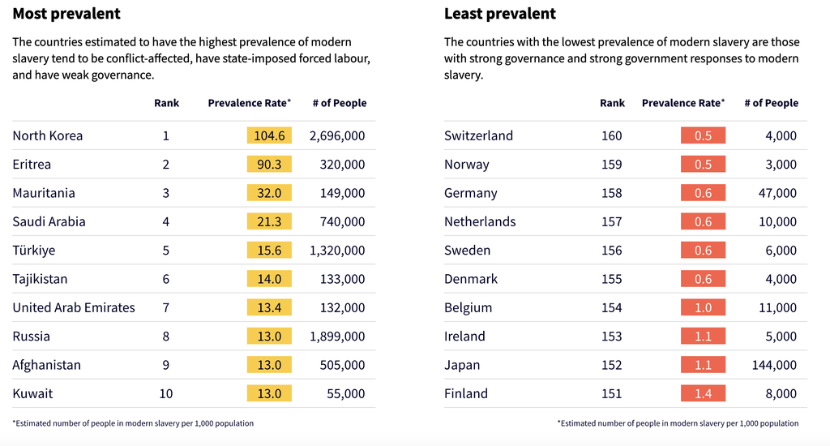

Figure 4: Original plot visualizing countries with the highest and lowest estimated prevalence of modern slavery. Source: Walk Free

This is an interesting dataset that reminds me of some work that I contributed to at the Pardee Center. There’s a lot that could be explored here, including things like mapping or analyzing the data with cluster analysis or PCA.

I like a chart to display this information, but there’s some elements that I’ll reconsider:

- The **color encoding of prevalence rate has no meaning**. It’s also odd/counterintuitive to use yellow for the countries with the highest prevalence and red for those with the lowest.
- The **chart titles aren’t clear as a standalone**, and I typically prefer to make charts that can be lifted from reports while maintaining enough context to explain.
- The **number of people estimated to be in modern slavery is washed out** by the prevalence rates. Yes, prevalence rate likely corresponds to the subtitle of the charts – countries with poor governance or high conflict zones are likely to have higher rates of slavery. But I couldn’t help but notice Japan’s estimate is very high, despite it being among the bottom 10 in prevalence rate. There could be something there to work on. Maybe adding a column for percentile rank of the number of people estimated to be in slavery conditions.
- Slicing this and show the top and bottom 10 by prevalence rate is an efficient use of space, but the distribution of **prevalence rate is heavily skewed, which seems to make that approach less meaningful**.
- I’d like to **add the country flags** to the table, because it’s a small design element that improves the recognition of some countries (at least for some). I have never used the {tidycountries} package, so I’ll give that a try.

# 6. Visualization Parameters

```r
region_cols <- c('Asia and the Pacific' = "#8dd3c7",
                 'Europe and Central Asia' = "#ffffb3",
                 'Africa' = "#bebada",
                 'Americas' = "#fb8072",
                 'Arab States' = "#80b1d3")

region_cols_alpha <- sapply(region_cols, alpha, alpha = 0.2)

my_theme <- theme(
  text = element_text(family = 'Lato', size=12, color='black'),
  axis.ticks = element_blank(),
  plot.background = element_rect(color='white'),
  panel.background =  element_blank(),
  legend.background = element_blank(),
  panel.grid.major = element_blank(),
  panel.grid.minor = element_blank(),
  panel.border = element_blank(),
  legend.title=element_blank(),
  legend.position = 'none')
```